# Replication of Surveillance Cues Enhance Moral Condemnation by Bourrat, Baumard, & McKay (2011, Evolutionary Psychology)

Catie Connolly (catiec@stanford.edu)

November 23, 2020

## Introduction

### Experiment Summary

The researchers found a significant difference between conditions such that individuals in the experimental condition rated the moral transgressions as less acceptable than individuals in the control condition. This finding suggests that even a very subtle cue of being watched can cause people to make harsher moral judgments. I aim to replicate these findings.

### Project Justification

I am currently inexperienced in R and hope to develop my skills further by building a project from scratch. By collecting my own data and cleaning/tidying that data, as well as by analyzing a 2x2 experimental paradigm, I will be developing skills that will be of great use to me throughout grad school. Furthermore, I am interested in cooperation between individuals and the ways in which we portray ourselves as “cooperative”, and am interested in whether this finding will replicate, thus suggesting that strong demonstrated morals are somehow demanded by social circumstances. Furthermore, I hope to probe questions about how we define identity, and how identity can shift contextually according to the characteristics of a given situation. Thus, looking at a minimal paradigm like the one in this experiment, and the ways in which it may still impact moral judgments in meaningful ways, will be an exciting way to better understand how we conceptualize our identity in the real or imagined presence of others.

### Required Stimuli and Expected Procedure

This experiment will require no physical materials, given that the experiment will be entirely online via the MTurk online crowdsourcing platform (due to the in-person restrictions place on research by the COVID-19 pandemic, as well as time and resource constraints). While the original experiment took place in person, the participant was always alone during the study, thus justifying the use of MTurk since in-person experimenters were not necessary to carry out the study.

The original study was conducted with 91 volunteers from a Paris University, and participants were not compensated for their participation. Given MTurk participants are unlikely to complete an unpaid study, participants in the replication study will be paid a small fee for their time.

### Anticipated Challenges

I anticipate that cleaning and tidying data from 91 participants will prove challenging, given that I have not worked with datasets in R in the past. In general, analyzing my own dataset for the first time combined with utilizing R to do so is a necessary challenge I will have to overcome to better develop both my R and data analysis chops.

### Related Links

The GitHub repository for this replication project can be found [here.](https://github.com/psych251/bourrat2011)

The original paper and subject of the replication project can be found [here.](https://github.com/psych251/bourrat2011/blob/master/original_paper/bourrat2011.pdf)

The preregistration for this replication project can be found [here.](https://osf.io/rhfzg)

## Methods

### Power Analysis

The original effect size of the Mann Whitney U test used (the key statistic for this replication study) was d = 0.78, or f = 0.39 (calculated independently, given that it was not provided by the authors in the original paper). In order to achieve 80% power, 46 participants are needed.

Given that the study is very short and hence will not be expensive to run on MTurk, and concerns regarding the differences between the original and current replication study (the online format, population, etc.) I plan to use the original sample size to match the original experiment as closely as possible.

### Planned Sample

I anticipate collecting data from approximately 91 mTurkers to match the original sample size. I will limit the sample to American mTurkers who are fluent in English in order to ensure that participants are able to complete the survey to the best of their ability.

### Materials

The original study used vignettes printed on A4 sheets of paper, with a picture of either eyes or flowers (depending on condition assignment) before a Likert scale. Given that the replication study will be conducted on Qualtrics via mTurk, the original stimuli will be presented in an online format, keeping all formatting equivalent to the greatest extent possible.

### Procedure

“Ninety-one participants were recruited in various libraries of the Campus Universitaire de Jussieu in Paris. Participation was voluntary and without remuneration. In an effort to minimize conscious concerns about the reputational consequences of their responses (which we felt might swamp the more subtle effects of our independent variable), we elected not to collect any personal (e.g., demographic) information from participants.”

Given that this replication study will be conducted over mTurk, we will instead sample from the available worker population. Additioanlly, the original stimuli were presented in French–because the current researcher is not familiar with French, the replication study will instead use a US population and present all stimuli in English. This study will also pay mTurkers a small fee for their time rather than avoid remuneration altogether. Finally, like the original study, we will avoid collecting demographic information so as to avoid activating identity-relevant concepts that may interfere with participant responses to the moral vignettes by invoking a sense of moral duty.

“Each participant was given two vignettes to read, printed on opposite sides of a single A4 sheet of paper. The vignettes were taken from Schnall, Haidt, Clore and Jordan (2008), and each described a moral violation: finding a wallet and keeping the money in one case, and falsifying a resume in the other (see the appendix for the original English versions, which were translated into French for the present study). Participants were instructed to rate the moral acceptability of each vignette on a nine-point Likert scale printed at the bottom of the page (1 = Morally unacceptable; 9 = Morally acceptable). Participants were directed to complete the task alone. The experimenter returned a few minutes later to collect the completed sheets.”

As stated above, the printed stimuli will instead be presented in an online survey format on Qualtrics via mTurk. Otherwise, the stimuli will be identical to those used in the original study.

“Participants were assigned randomly to one of two conditions. In the eyes condition (n = 43) a 47 x 17 mm image of a pair of eyes (see Figure 1a) was displayed on each side of the sheet between the vignette and the associated Likert scale. In the flowers condition (n = 48) the image was of white flowers (see Figure 1b).”

This aspect of the experiment will be carried out exactly as specified in the original paper.

### Analysis Plan

“As the data were not normally distributed, we used a non-parametric test for our analyses. For the wallet vignette, the median rating of moral acceptability was 2 in the eyes condition and 3 in the flowers condition; the distributions in the two conditions were significantly different (Mann-Whitney U = 789, p = 0.024, one- tailed). For the resume vignette, the median rating was 3 in the eyes condition and 5 in the flowers condition; the distributions in the two conditions again differed significantly (Mann–Whitney U = 750, p = 0.016, one-tailed).”

The above excerpt from the original paper specifies the data analysis strategy utilized. Assuming this replication project also produces data that is not normally distributed, I will use the Mann-Whitney U Test (Wilcoxon Rank Sum) to analyse whether the distributions of moral evaluations in the two conditions are statistically significant.

If, however, the data are normally distributed, I will instead use a t-test as the main analysis of interest.

Currently, there are no expectations that data will need to be excluded. In order to assess the question of interest (whether the condition of eyes or flowers impacts moral evaluations), data will be organized by vignette to best assess the impact of each condition on moral evaluation of each respective vignette.

### Differences from Original Study

The most important differences between the original study and replication study are 1) the demographic characteristics of the sample, namely location and language, and 2) method of survey presentation.

Regarding 1), given the current researcher’s knowledge base and lack of knowledge of French, this study will be conducted in English using a United States-based population. The original paper provided the English version of the vignettes, which will be used verbatim. Country of residence and ethnicity were not considered important factors in the original study, indicating that the orignally observed effect should generalize across populations. Similarly, it is important to note that the original study utilized convenience sampling amongst French university students, while the current study will more broadly sample from American mTurkers; again, this was not mentioned as specifically relevant in the original paper, and therefore we expect the original effects to persist in spite of this difference.

Regarding 2), the organization of this course as well as the current constraints on in-person studies due to the COVID-19 pandemic limit this study to online presentation only. Rather than distributing paper surveys, we will link mTurkers to a Qualtrics survey using the same design characteristics as the original study. Because the original study involved specifically leaving participants alone to fill out the study, there should be no issues presented by the lack of an in-person experimenter for this study. Additionally, because all stimuli was static in the original study, there is no reason to believe online presentation should alter the results.

### Methods Addendum (Post Data Collection)

#### Actual Sample

We collected data from 90 participants (45 participants in each of the two conditions).

The study was conducted with a US-based and English-speaking population.

66 participants were male (73% of total sample) and 23 participants were female (25% of total sample). 1 participant identified as non-binary (1% of total sample).

Regarding the age breakdown of the subjects, 5% of participants were 18-24 years old, 40% of participants were 25-34 years old, 33.3% of participants were 35-44 years old, 10% of participants were 45-54 years old, and 10% of participants were over 55.

In terms of racial identity, 71% of participants identified as White, 10% of participants identified as Black or African American, 6.6% of participants identified as Hispanic or Latino, 8.8% of participants identified as Asian, and 1% of participants identified as Native American or American Indian.

We did not exclude any data, given that the study was very short and it would be difficult to accurately weed out inattentive participants based on time spent taking the survey.

We did, however, set some important standards for participation in this study beforehand: partcipants needed to have a prior approval rating of 95% or greater, and participants needed to be English-speaking and located in the US.

## Results

### Data preparation

Data preparation following the analysis plan.

I plan to organize the data by vignette in order to compare the effects of condition within each vignette.

```r
#Import Data

library(readr)
mydata <- read_csv("https://raw.githubusercontent.com/psych251/bourrat2011/master/Bourrat%202011%20replication_finaldata.csv?token=ARBJXF4XMIPF6W2P6YE5XX27XQPG2")
# Load libraries
library(foreign) # for reading spss formatted data
library(tidyr)
library(dplyr)
```

```r
library(stringr) # useful for some string manipulation
library(ggplot2)
library(knitr)

# Rename data
names(mydata) <- sub("^FL_11_DO$", "condition", names(mydata))
names(mydata) <- sub("^Q1_1$", "wallet_control", names(mydata))
names(mydata) <- sub("^Q2_1$", "resume_control", names(mydata))
names(mydata) <- sub("^Q8_1$", "wallet_experimental", names(mydata))
names(mydata) <- sub("^Q9_1$", "resume_experimental", names(mydata))

# Read column names
colnames(mydata)
```

```
##  [1] "StartDate"             "EndDate"               "Status"
##  [4] "IPAddress"             "Progress"              "Duration (in seconds)"
##  [7] "Finished"              "RecordedDate"          "ResponseId"
## [10] "RecipientLastName"     "RecipientFirstName"    "RecipientEmail"
## [13] "ExternalReference"     "LocationLatitude"      "LocationLongitude"
## [16] "DistributionChannel"   "UserLanguage"          "wallet_control"
## [19] "resume_control"        "wallet_experimental"   "resume_experimental"
## [22] "Q10"                   "Q11"                   "Q11_5_TEXT"
## [25] "Q12"                   "Q12_7_TEXT"            "mTurk"
## [28] "condition"             "wallet"                "resume"
```

### Confirmatory analysis

First, I will present the data in histograms by vignette to provide a visualization of the data collected for this replication study.

I will then analyze the data, organized into the two vignettes and the two conditions within each vignette, using the one-tailed Mann-Whitney U test to compare the impact of condition on moral evaluation of each respective vignette.

I will also produce graphs comparing the mean moral acceptability ratings within each vignette (wallet versus resume), grouped by condition (control versus experimental).

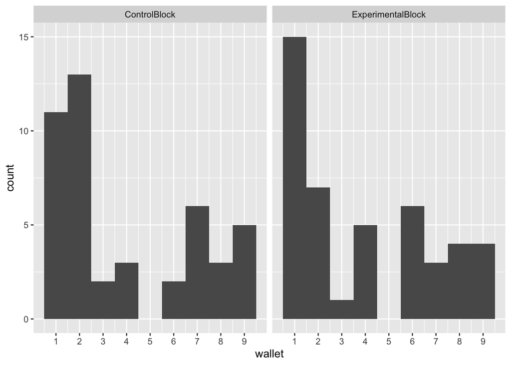

```r
#Plot Data
#Histogram - counts

ggplot(mydata, aes(x = wallet)) +
  geom_histogram(
    binwidth = 1,
    center = 1,
  ) +
  facet_wrap(~condition) +
  scale_x_continuous(
    breaks=seq(1,10,1)
  )
```

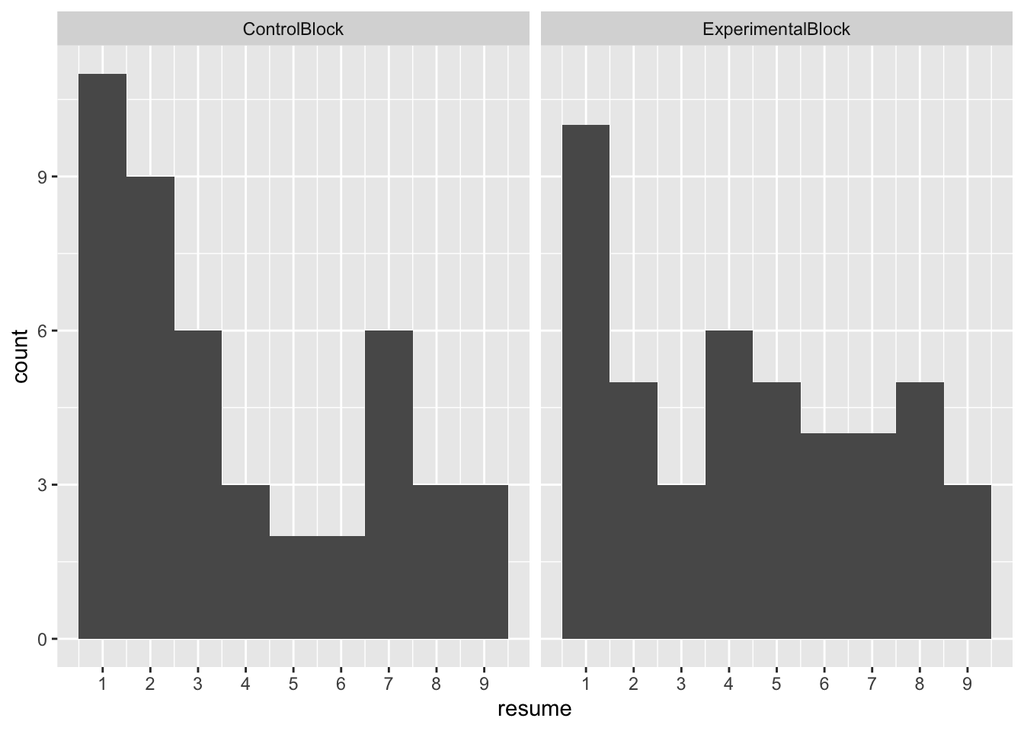

```r
ggplot(mydata, aes(x = resume)) +
  geom_histogram(
    binwidth = 1,
    center = 1,
  ) +
  facet_wrap(~condition) +
  scale_x_continuous(
    breaks=seq(1,10,1)
  )
```

```r
#Main statistical test - Wilcoxon

mydata %>% select(wallet_control:condition)
```

```
## # A tibble: 90 x 11
##    wallet_control resume_control wallet_experime… resume_experime… Q10   Q11
##             <dbl>          <dbl>            <dbl>            <dbl> <chr> <chr>
##  1              1              2               NA               NA 35-4… Male
##  2             NA             NA                9                5 25-3… Fema…
##  3              1              2               NA               NA 35-4… Male
##  4             NA             NA                4                8 25-3… Male
##  5             NA             NA                1                1 35-4… Male
##  6              2              2               NA               NA 25-3… Male
##  7              2              4               NA               NA 25-3… Male
##  8             NA             NA                1                1 25-3… Male
##  9              2              1               NA               NA Over… Male
## 10             NA             NA                2                4 35-4… Male
## # … with 80 more rows, and 5 more variables: Q11_5_TEXT <chr>, Q12 <chr>,
## #   Q12_7_TEXT <chr>, mTurk <lgl>, condition <chr>
```

```r
testdata <- as.data.frame(apply(mydata[,18:21], MARGIN=2, FUN=as.integer))

wilcox.test(x=testdata$wallet_control, y=testdata$wallet_experimental, alternative=c("greater"), na.rm = TRUE)
```

```
##
##  Wilcoxon rank sum test with continuity correction
##
## data:  testdata$wallet_control and testdata$wallet_experimental
## W = 1051.5, p-value = 0.3757
## alternative hypothesis: true location shift is greater than 0
```

```r
wilcox.test(x=testdata$resume_control, y=testdata$resume_experimental, alternative=c("greater"), na.rm = TRUE)
```

```
##
##  Wilcoxon rank sum test with continuity correction
##
## data:  testdata$resume_control and testdata$resume_experimental
## W = 903.5, p-value = 0.8141
## alternative hypothesis: true location shift is greater than 0
```

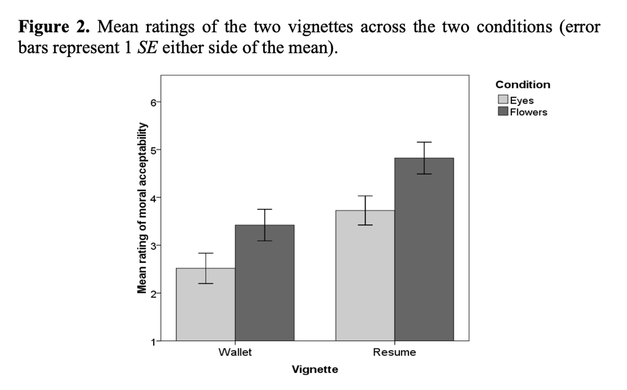

```r
# Mean Moral Acceptability Plots
# Original plot of mean moral acceptability from Bourrat 2011

knitr::include_graphics("https://github.com/psych251/bourrat2011/blob/master/images/bourrat2011_mainplot.png?raw=true")
```

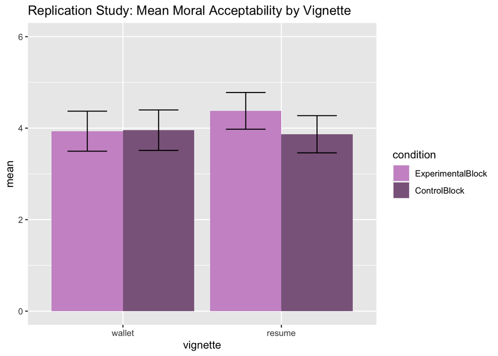

```r
#Replication plot of means

test <- mydata %>%
  select(c("condition", "resume", "wallet")) %>% #select relevant variables
  pivot_longer(cols=c("resume", "wallet"), names_to="vignette", values_to="result") #organize data for plot

test$vignette = factor(test$vignette, levels=c("wallet", "resume"), ordered=TRUE) #create vignette factors, order presentation of vignettes
test$condition = factor(test$condition, levels=c("ExperimentalBlock","ControlBlock"), ordered=TRUE) #create condition factor, order presentation of conditions

# Produce means plot
test %>%
  group_by(condition, vignette) %>%
  summarize(mean=mean(result), se=sd(result)/sqrt(n())) %>% #Produce means and error bars
  ggplot(aes(x=vignette, y=mean, fill=condition)) + #Fill by condition
  geom_bar(stat="identity", position="dodge") +
  geom_errorbar(position=position_dodge(0.9),
                width= .5,
                aes(ymin=mean-se,
                    ymax=mean+se)) +
  ylim(0,6) +
  scale_fill_manual(values=c("plum3", "plum4")) +
  ggtitle("Replication Study: Mean Moral Acceptability by Vignette")
```

## Discussion

### Summary of Replication Attempt

The primary result was the Mann-Whitney U test. The test was one-tailed and assessed whether the moral acceptability ratings were lower in the experimental condition than in the control condition (implying people were more morally condemning when they saw surveillance cues). For the wallet vignette, we found a U of 1051.5 with a p-value of 0.3757. For the resume vignette, we found a U of 903.5 with a p-value of 0.8141. In the original study, the authors found a U of 789 with a p-value of 0.024 for the wallet vignette, and a U of 750 with a p-value of 0.016 for the resume vignette.

We failed to replicate the original findings, with non-significant results indicating that moral acceptability scores in the experimental conditions were no lower than moral acceptability scores in the control conditions for both vignettes. Regarding the resume vignette, the data actually seems to be trending in the opposite direction from the original findings, suggesting that participants in the experimental condition may have found that vignette more morally acceptable relative to participants in the control condition.

### Commentary

No exploratory analyses were conducted due to lack of sufficient time to carry them out.

One key difference between the original study and the replication study was the mode of presentation. While the original study was conducted in-person using a double-sided paper survey, the current replication study was conducted on MTurk via Qualtrics. While all efforts were made to make the presentation otherwise identical, and confirmation was received from the original paper authors confirming that the stimuli used for the replication were very similar to those which were used in the original study, it is possible that the environment in which the study was conducted affected results. Given the importance of the idea of “surveillance cues” to the study, these results may call into question whether these sorts of cues are only effective in specific environments. The eyes are, as the original authors would argue, a mechanism that causes the participant to feel as though they are being watched, perhaps activating an evolutionary mechanism sensitive to surveillance and social cues. The original study, conducted in a public location, might have more effectively activated this cue. On the other hand, our remote study conducted via the internet might be less effective in activating this cue. If a person is aware that they are alone and simply operating their computer, they may not be sensitive to cues that indicate social surveillance.

Furthermore, it is also possible that the means of collecting data affected partcipants’ approach to the experiment. While in the original study participants interfaced directly with the researchers before completing the survey, our participants had the far more socially-distant experience of completing the survey based off a posted link, with no real interaction with the researchers. It’s possible that, to some extent, the in-person interfacing helped to facilitate the surveillance effect, such that the effect would not be observable in a setting where researchers are not physically present.

The original experiment was also conducted with a French and French-speaking population, whilst the replication was conducted with an American and English-speaking population. Although possible, it is unlikely that these differences in results were due to a cultural or language-related difference in populations, particularly considering the extent to which the results failed to replicate. Furthermore, given that the original author provided written confirmation that the presentation of the stimuli matched (in online format) the original study materials, it seems unlikely that translation would be the difference driving the lack of replication.